# Robust Growth Mixture Models

```r
library(RobustLPA)
set.seed(2026)
```

## 1. From profiles to trajectories

`robust_lpa()` finds latent profiles in variables measured once. When the same variables are measured repeatedly, the question often becomes *how people change*: do they all follow one average trajectory, or are there subgroups with different courses (stable, slowly declining, rapidly declining)? Growth mixture models (GMM; Verbeke & Lesaffre, 1996; Muthen & Shedden, 1999) answer this question: they are finite mixtures of linear mixed-effects models, in which every latent class has its own mean trajectory, and persons deviate from their class trajectory through random effects. Without random effects the model is a latent class growth analysis (LCGA; Nagin, 1999).

`robust_gmm()` fits these models for one or several outcomes at once, with

- **unbalanced data**: every person contributes the likelihood of the values actually observed, at his/her own times, so persons with missed visits or who dropped out are kept, and the estimates are valid when drop-out depends on earlier observed values (missing at random);
- **robust classes**: multivariate-t classes (`robust_method = "t"`), whose heavy tails absorb persons with outlying trajectories or gross errors instead of creating spurious classes;
- **two estimation engines** (EM and MCMC); and
- **LASSO penalties** that identify classes that do not change on an outcome and outcomes that do not differ between classes.

## 2. Example data

`neuro_long` contains simulated annual assessments (up to six visits) of 400 persons on three tests, in long format. Three latent classes were simulated: a stable class, a slowly declining class and a fast declining class on `Memory` and `Executive`; `Speed` declines slightly and equally in all classes. Persons drop out more often after a low Memory score, and a few scores are corrupted by gross errors (see `?neuro_long`).

```r
data(neuro_long)
head(neuro_long)
```

```
#>   ID Year Memory Executive Speed   True_Class  Age Biomarker
#> 1  1    0   53.3      53.7  42.2 Slow decline 60.5       924
#> 2  1    1   45.8      51.1  48.1 Slow decline 60.5       924
#> 3  1    2   49.0      44.1  43.4 Slow decline 60.5       924
#> 4  1    3   46.4      46.0  42.0 Slow decline 60.5       924
#> 5  1    4   41.6      40.9  41.1 Slow decline 60.5       924
#> 6  1    5   39.2      42.4  40.6 Slow decline 60.5       924
```

```r
table(visits = table(neuro_long$ID))
```

```
#> visits
#>   1   2   3   4   5   6
#>  19  20  26  32  29 274
```

## 3. Fitting a robust growth mixture model

The data are in long format: one row per person and visit, with the person identifier (`id`), the time variable (`time`, here years since baseline, so that the intercept is the baseline level) and the outcomes. By default every class has a linear trajectory (`degree = 1`), persons have correlated random intercepts and slopes (`random = "slope"`), and the random-effect covariance and the residual variances are shared by the classes (`re_cov = "equal"`, `resid_var = "equal"`), the usual and more stable specification.

```r
fit <- robust_gmm(neuro_long, id = "ID", time = "Year",
                  outcomes = c("Memory", "Executive"), G = 3,
                  robust_method = "t", n_starts = 3)
fit
```

```
#> <robust_gmm> EM | G = 3 | persons = 400 | outcomes: Memory, Executive
#> Trajectory: degree 1 | random: slope (full, equal across classes) | robust: multivariate t (nu = 10.27)
#> LogLik = -10536.7 | BIC = 21235.3 | Entropy = 0.801
#> Proportions: C1=0.18, C2=0.50, C3=0.32
```

The estimated trajectories are on the original scale of the outcomes:

```r
summary(fit)
```

```
#> robust_gmm summary -- EM | G = 3 | persons = 400
#> Estimation: robust: multivariate t (nu = 10.27) | degree 1 | random: slope
#>
#> Class trajectories (original scale):
#>  Class   Outcome (Intercept)   Year
#>      1    Memory      44.966 -5.050
#>      1 Executive      42.888 -3.968
#>      2    Memory      53.393 -0.037
#>      2 Executive      52.273 -0.074
#>      3    Memory      48.556 -2.135
#>      3 Executive      47.854 -1.664
#>
#> Class sizes (modal assignment):
#>  Class   N Proportion
#>      1  78      0.185
#>      2 198      0.499
#>      3 124      0.316
#>
#> Random-effect covariance (equal across classes; class 1 shown):
#>                       Memory:(Intercept) Memory:Year Executive:(Intercept)
#> Memory:(Intercept)                18.116       0.375                 9.787
#> Memory:Year                        0.375       0.053                 0.090
#> Executive:(Intercept)              9.787       0.090                22.239
#> Executive:Year                    -0.162       0.083                 0.384
#>                       Executive:Year
#> Memory:(Intercept)            -0.162
#> Memory:Year                    0.083
#> Executive:(Intercept)          0.384
#> Executive:Year                 0.224
#>
#> Residual variances:
#>         Memory Executive
#> Class_1   6.63     5.639
#> Class_2   6.63     5.639
#> Class_3   6.63     5.639
#>
#> Fit: LogLik = -10536.74 | Parameters = 27 | AIC = 21127.5 | BIC = 21235.3 | SABIC = 21149.6 | Entropy = 0.801
```

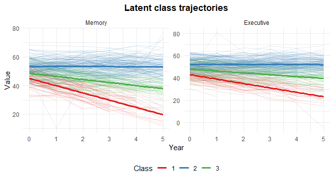

```r
plot_robust_gmm(fit)
```

`fit$probabilities` and `fit$assignments` give the posterior class probabilities and the modal class of every person (in the order of `fit$ids`); `fit$weights` gives each person’s robustness weight, which is small for the persons whose trajectory is far from every class (here, the persons with a gross error):

```r
head(sort(fit$weights))
```

```
#> [1] 0.1016763 0.1031012 0.1155740 0.1194273 0.1233247 0.1260103
```

## 4. How many classes? Robust vs. classical estimation

`estimate_gmm_robust()` fits several numbers of classes at once. Comparing the classical (Gaussian) and the robust (t) models shows why robustness matters here: the classical model uses an extra class to accommodate a handful of persons with gross errors (note its minimum class size), and BIC then favours too many classes; the t model does not.

```r
classical <- estimate_gmm_robust(neuro_long, id = "ID", time = "Year",
                                 outcomes = c("Memory", "Executive"),
                                 n_classes = 2:4, robust = FALSE, n_starts = 2)
robust <- estimate_gmm_robust(neuro_long, id = "ID", time = "Year",
                              outcomes = c("Memory", "Executive"),
                              n_classes = 2:4, robust_method = "t", n_starts = 2)
classical$fit_table[, c("Model", "LogLik", "BIC", "Entropy", "Min_Size")]
```

```
#>      Model    LogLik      BIC   Entropy Min_Size
#> 1 G2_slope -10816.56 21758.93 0.7899989   0.2150
#> 2 G3_slope -10771.35 21698.48 0.8195362   0.1900
#> 3 G4_slope -10743.39 21672.52 0.8552182   0.0025
```

```r
robust$fit_table[, c("Model", "LogLik", "BIC", "Entropy", "Min_Size")]
```

```
#>      Model    LogLik      BIC   Entropy Min_Size
#> 1 G2_slope -10586.20 21304.21 0.7703904   0.2175
#> 2 G3_slope -10536.74 21235.26 0.8009036   0.1950
#> 3 G4_slope -10531.26 21254.25 0.7414121   0.0750
```

With the t model the log-likelihood is a proper likelihood, so the bootstrapped likelihood ratio test can complement BIC. It simulates data from the fitted `G - 1`-class model on the observed visit schedule and missingness pattern (slow: use 200 or more samples and several cores):

```r
blrt_gmm_robust(neuro_long, id = "ID", time = "Year",
                outcomes = c("Memory", "Executive"), G = 3,
                robust_method = "t", n_samples = 200, cores = 4)
```

## 5. LASSO for trajectories

With several outcomes, two questions are natural: *on which outcomes does each class actually change?* and *which outcomes differentiate the classes at all?* Two penalties answer them:

- `lambda_growth` shrinks the growth terms (slope, …) of every class toward zero: a slope set exactly to zero identifies a class that is stable on that outcome;
- `lambda_diff` shrinks the trajectories of the classes toward each other; with `group_diff = TRUE` all the coefficients of an outcome are penalized together, so an outcome that does not differ between classes is removed from the class separation.

The penalties are adaptive by default: each term is weighted by its unpenalized estimate, so that `lambda = z^2 / N` sets to zero, roughly, the terms whose Wald statistic is below `z`. Here `z = 3`:

```r
N <- length(unique(neuro_long$ID))
fit_l <- robust_gmm(neuro_long, id = "ID", time = "Year",
                    outcomes = c("Memory", "Executive", "Speed"), G = 3,
                    robust_method = "t", n_starts = 2,
                    lambda_growth = 9 / N, lambda_diff = 9 / N, group_diff = TRUE,
                    relax = TRUE)
summary(fit_l)
```

```
#> robust_gmm summary -- EM | G = 3 | persons = 400
#> Estimation: robust: multivariate t (nu = 10.30) | degree 1 | random: slope
#>
#> Class trajectories (original scale):
#>  Class   Outcome (Intercept)   Year
#>      1    Memory      45.136 -5.004
#>      1 Executive      43.115 -3.937
#>      1     Speed      50.105 -0.606
#>      2    Memory      48.822 -2.132
#>      2 Executive      47.988 -1.643
#>      2     Speed      50.105 -0.606
#>      3    Memory      53.208  0.000
#>      3 Executive      52.145  0.000
#>      3     Speed      50.105 -0.606
#>
#> Class sizes (modal assignment):
#>  Class   N Proportion
#>      1  77      0.183
#>      2 123      0.318
#>      3 200      0.499
#>
#> Random-effect covariance (equal across classes; class 1 shown):
#>                       Memory:(Intercept) Memory:Year Executive:(Intercept)
#> Memory:(Intercept)                19.256       0.394                10.520
#> Memory:Year                        0.394       0.047                 0.104
#> Executive:(Intercept)             10.520       0.104                23.248
#> Executive:Year                    -0.116       0.073                 0.380
#> Speed:(Intercept)                 10.519      -0.231                11.665
#> Speed:Year                         0.073       0.031                 0.144
#>                       Executive:Year Speed:(Intercept) Speed:Year
#> Memory:(Intercept)            -0.116            10.519      0.073
#> Memory:Year                    0.073            -0.231      0.031
#> Executive:(Intercept)          0.380            11.665      0.144
#> Executive:Year                 0.229            -0.438      0.070
#> Speed:(Intercept)             -0.438            24.004      0.250
#> Speed:Year                     0.070             0.250      0.076
#>
#> Residual variances:
#>         Memory Executive Speed
#> Class_1  6.875     5.695 6.675
#> Class_2  6.875     5.695 6.675
#> Class_3  6.875     5.695 6.675
#>
#> Fit: LogLik = -15699.01 | Parameters = 39 | AIC = 31476.0 | BIC = 31631.7 | SABIC = 31507.9 | Entropy = 0.815
#>
#> LASSO: growth = 0.0225, difference = 0.0225 (group by outcome), adaptive weights, estimates from the relaxed (unpenalized) refit
#> Outcomes differentiating the classes: Memory, Executive (removed: Speed)
#> Growth terms set to zero: 2 of 9
```

`Speed` is recognized as an outcome that does not differentiate the classes (the three classes share its trajectory), and the stable class has exactly zero slopes on `Memory` and `Executive`. With `relax = TRUE` the selected model is refitted without penalty (relaxed Lasso), so the reported estimates are not shrunk; its BIC counts only the free coefficients, and is lower than the BIC of the unpenalized three-outcome model:

```r
fit_u <- robust_gmm(neuro_long, id = "ID", time = "Year",
                    outcomes = c("Memory", "Executive", "Speed"), G = 3,
                    robust_method = "t", n_starts = 2)
rbind(unpenalized = fit_u$fit[, c("LogLik", "Parameters", "BIC")],
      lasso_relaxed = fit_l$fit[, c("LogLik", "Parameters", "BIC")])
```

```
#>                  LogLik Parameters      BIC
#> unpenalized   -15697.92         45 31665.45
#> lasso_relaxed -15699.01         39 31631.69
```

Instead of fixing `z`, `estimate_gmm_robust(tune_penalty = "bic")` or `tune_penalty = "cv"` (cross-validation over persons) chooses it from a grid:

```r
estimate_gmm_robust(neuro_long, id = "ID", time = "Year",
                    outcomes = c("Memory", "Executive", "Speed"), n_classes = 3,
                    tune_penalty = "bic", z_grid = c(1.5, 2, 2.5, 3, 4),
                    robust_method = "t", group_diff = TRUE, relax = TRUE)
```

## 6. What distinguished the classes at baseline?

`bch_robust()` relates the trajectory classes to a variable that was not used to estimate them – a baseline characteristic or a distal outcome – correcting for classification error (Bolck, Croon & Hagenaars, 2004). The auxiliary variable must have one value per person, in the order of `fit$ids`:

```r
baseline <- neuro_long[!duplicated(neuro_long$ID), ]
baseline <- baseline[match(fit$ids, baseline$ID), ]
bch_biomarker <- bch_robust(fit, baseline$Biomarker)
round(bch_biomarker$Profile_Means)
```

```
#> Profile_1 Profile_2 Profile_3
#>       696       895       851
```

```r
bch_biomarker$ANOVA_Table
```

```
#>            Df  Sum_Sq    Mean_Sq  F_value      p_value
#> Class       2 2160216 1080108.18 47.83063 2.449367e-19
#> Residuals 397 8965027   22581.93       NA           NA
```

For publication, `correction = "bootstrap"` adds standard errors that account for the uncertainty of the classification (whole persons are resampled and the growth mixture model is refitted every time).

## 7. Bayesian estimation

The MCMC engine fits the same models by Gibbs sampling (with the LASSO penalties turned into Bayesian-Lasso priors). It starts from the EM solution and reports the WAIC and the Gelman-Rubin diagnostics:

```r
fit_b <- robust_gmm(neuro_long, id = "ID", time = "Year", outcomes = "Memory",
                    G = 3, robust_method = "t", engine = "MCMC",
                    mcmc_iter = 600, n_chains = 2, n_starts = 2)
fit_b
```

```
#> <robust_gmm> MCMC | G = 3 | persons = 400 | outcomes: Memory
#> Trajectory: degree 1 | random: slope (full, equal across classes) | robust: multivariate t (nu = 6.58)
#> LogLik = -5450.8 | BIC = 10979.4 | Entropy = 0.738 | WAIC = 10926.0
#> Proportions: C1=0.19, C2=0.31, C3=0.51
```

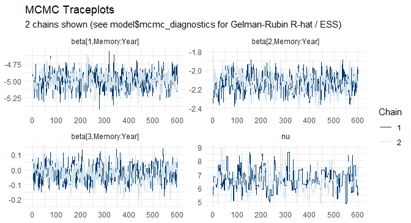

```r
plot_mcmc_chains(fit_b, pars = c("beta[1,Memory:Year]", "beta[2,Memory:Year]",
                                 "beta[3,Memory:Year]", "nu"))
```

## 8. Practical recommendations

- Express time in meaningful units and center it where the intercept should be interpreted (e.g. years since baseline).
- Start with shared variance components (`re_cov = "equal"`, `resid_var = "equal"`) and a random intercept and slope; free them only if the data support it (compare BIC).
- Use several starts (`n_starts`) and check the smallest class size: tiny classes are often spurious.
- Prefer `robust_method = "t"`: it keeps a proper likelihood, so BIC, the BLRT and BCH are used as intended.
- Use the LASSO to *select*, and report the relaxed estimates (`relax = TRUE`).

## References

Bolck, A., Croon, M., & Hagenaars, J. (2004). Estimating latent structure models with categorical variables: One-step versus three-step estimators. *Political Analysis*, 12(1), 3-27.

Muthen, B., & Shedden, K. (1999). Finite mixture modeling with mixture outcomes using the EM algorithm. *Biometrics*, 55(2), 463-469.

Nagin, D. S. (1999). Analyzing developmental trajectories: A semiparametric, group-based approach. *Psychological Methods*, 4(2), 139-157.

Pinheiro, J. C., Liu, C., & Wu, Y. N. (2001). Efficient algorithms for robust estimation in linear mixed-effects models using the multivariate t distribution. *Journal of Computational and Graphical Statistics*, 10(2), 249-276.

Verbeke, G., & Lesaffre, E. (1996). A linear mixed-effects model with heterogeneity in the random-effects population. *Journal of the American Statistical Association*, 91(433), 217-221.

Xie, B., Pan, W., & Shen, X. (2008). Variable selection in penalized model-based clustering via regularization on grouped parameters. *Biometrics*, 64(3), 921-930.

Zou, H. (2006). The adaptive lasso and its oracle properties. *Journal of the American Statistical Association*, 101(476), 1418-1429.